# HOmics vignette

Lara Nonell

12 jul. 2019

# 1 Introduction

**HOmics** is an R package to integrate omics data by capturing hierarchical relations between omics in their association to phenotype. It contains two main functions, the generic **HOmics()** function and **HOmics.meth()**, to analyze specifically methylation of genes affecting a phenotype. Details on how to apply this latter function are available in the HOmics methylation gene integration vignette.

# 2 Installation

**HOmics** fits Bayesian models through the package *rjags*, which needs the JAGS (Just Another Gibbs Sampler) environment to be installed. JAGS is a program for the analysis of Bayesian hierarchical models using Markov Chain Monte Carlo (MCMC) simulation. You can install JAGS easily through this link: http://mcmc-jags.sourceforge.net/ Once JAGS is installed you only need to install the **HOmics** package:

```r
# library(devtools)
# install_github("lnonell/HOmics")

library(HOmics)
```

HOmics depends on the following R packages:

- Biobase
- doParallel
- foreach
- minfi
- rjags
- MCMCvis
- dplyr
- purrr
- ggplot2

# 3 The model

**HOmics** fits a Bayesian hierarchical model for each group of features specified. The steps to fit each model are the following:

1. Selects a group of features to model their association to phenotype
2. Fits the likelihood (first level in the hierarchical model) accounting for the prior information (second level of the hierarchical model). *rjags* is used to fit the hierarchical model with the MCMC approach. These are the steps internally taken to fit the model and get the results:
3. The model is initially fitted with three Markov chains and default initial values
4. The model then is updated in the *burn in* phase, with 2000 iterations
5. Coefficients (beta estimates) for all features are obtained for the posterior distribution by sampling, with 1000 iterations
6. Function MCMCsummary of package *MCMCvis* is used to obtain summaries

Convergence has been tested in simulated data with these parameters and the three Markov chains were considerably stable.

# 4 Data

As previously stated, **HOmics** fits a Bayesian hierarchical model for a group of features. For that the **agg.matrix** is needed.

Input data parameters for main function **HOmics** are the following:

- **data.matrix**: measurements of *m* features in *n* samples. Matrix with features as rows and samples as columns. It can be for instance a gene expression matrix or a matrix of CpGs beta-values.
- **agg.matrix**: aggregation matrix for features. Each row represents a group. It must contain features as columns and the aggregation criteria as rows. If a feature belongs to a group in its corresponding row and columns position should be a 1, if not a 0. A model will be fitted with the selected features in each row by selecting those with 1s. It can be for instance a matrix of genes belonging to functions or genes close to CpGs.
- **cond**: condition, response or phenotype variable. Usually a numerical factor with two levels representing the conditions to compare although it can be a continuous vector too. If **cond** is numerical (continuous response), a hiearchical linear regression model will be fitted instead of the default hierarchical logistic regression model. Details on this parameter are to be found below.
- **z.matrix**: matrix with prior information related to features, with rownames the features and prior entities. It can be the miRNAs targeting genes specified in the data.matrix.
- **covar.matrix** (optional): vector with a covariate or matrix of continuous covariates, with samples as rownames (in the same order as cond) and covariates as columns. Default = NULL.
- **cores** (optional): cores in case of parallelization. Default = 1 (no parallelization).

Figure 1 summarizes the relationship among the different needed objects in the model hierarchy.

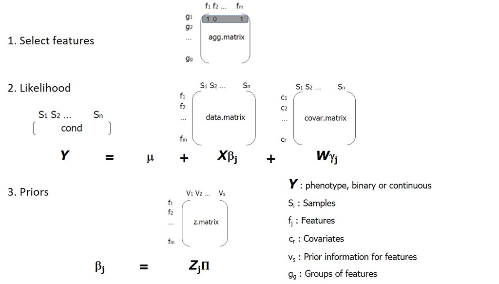

## 4.1 Response variable, phenotype or condition

**cond** is the response variable and should be a vector with the same length and order as samples in **data.matrix** (specified as columns). Response variable can be continuous or categorical but depending on its nature it will be transformed to fit the hiearachical model.

**HOmics** will fit a hierarchical logistic regression model when the response is binary or a hierarchical linear regression model if the response is continuous.

### 4.1.1 Categorigal responses

JAGS needs a vector of 0s and 1s, so vector **cond** will be converted if it is not such. The rules to convert it are the following:

- if **cond** is a factor, it will be converted to a vector of 0’s and 1’s. Remember when converting to factor in R, it assigns the levels in alphabetical order by default. So for instance, in the following code, for vector *a*, 2 will be taken as the level of reference. In this case, we would compare 4 vs 2. For vector *b*, **HOmics** will use “healthy” as the reference level and the comparison performed will be “tumor” vs “healthy”. You can use function *relevel()* to select a different reference level.
- if **cond** is a character variable, it will be converted to a numerical vector by converting it first to a factor.

This is the internal code used to transform the variable:

```r
a <- factor(c(2,4,4,2,4))
levels(a)
```

```
## [1] "2" "4"
```

```r
cond.a <- as.numeric(a)-1
cond.a
```

```
## [1] 0 1 1 0 1
```

```r
b <- c("tumor","healthy","tumor","tumor","healthy","healthy")
levels (b)
```

[output not shown]

```r
cond.b <- as.numeric(b)-1
cond.b
```

```
## [1] NA NA NA NA NA NA
```

### 4.1.2 Continuous responses

When the response variable is continuous, a hierarchical linear model will be fitted.

## 4.2 Covariates

The model accepts one or more covariates in parameter **covar.matrix**. **covar.matrix** can be a vector or a matrix but in both cases the values must be in the same sample order as **cond** and as the columns of **data.matrix**.

# 5 Parallelization

Parallelization is enabled with the use of packages *doParallel* and *foreach*, which should work in any operative system.

Parameter **cores** will enable parallelization in the functions. Use function *detectCores()* in *parallel* to retrieve the number of cores to work.

```r
library(parallel)
detectCores()
```

```
## [1] 8
```

# 6 The results

The output given by **HOmics** function is an object of class **Homics**. It contains a list of results for each analysis performed on each group of features.

For each element in the results object, a tibble, with the following columns is specified:

- mean, sd: mean and standar deviation of coefficients for all iterations in all chains (3000)
- 2.5%, 50%, 97.5%: specified percentiles for coefficients for all iterations in all chains (3000)
- Rhat: Potential scale reduction statistic (Rhat). Values near 1 suggest convergence
- n.eff: number of effective samples for each parameter. Should the higher the better

**HOmics** objects can be subsequently filtered with function **get.signif()** to get significative features or plotted with function **plot.res()**.

# 7 Example 1: Synthetic data

Let’s create some random but realistic data.

- 10 samples
- 50 features
- 8 groups of the 50 features
- the response is a factor of 0s and 1s having length 10

```r
s.n <- 10
f.n <- 50
z.n <- 10
g.n <- 8

#data.matrix, features with random normal distribution
data.matrix<-matrix(data = rnorm(500,5,3),nrow=f.n)
rownames(data.matrix) <- paste0("f",1:f.n)
colnames(data.matrix) <- paste0("s",1:s.n)

#aggregation of features g a
agg.matrix <- matrix(data = sample(rep(0:1,1000),400),nrow=g.n)
rownames(agg.matrix) <- paste0("g",1:g.n)
colnames(agg.matrix) <- paste0("f",1:f.n)

#prior matrix of features  belonging to z's
z.matrix<-matrix(data = sample(rep(0:1,1000),500),nrow=f.n)
rownames(z.matrix) <- paste0("f",1:f.n)
colnames(z.matrix) <- paste0("z",1:z.n)

#response
y <- rep(c(0,1),5)
cond <- as.factor(y)
```

Let’s apply the function **HOmics**, which will fit a hierarchical logistic model. As there are 8 groups specified in the agg.matrix, HOmics will fit 8 hierarchical models and return a list with 8 elements with the results.

```r
library(HOmics)

res<-HOmics(data.matrix = data.matrix,
            agg.matrix = agg.matrix,
            cond = cond,
            z.matrix =z.matrix,
            covar.matrix = NULL,
            cores = 4)
```

```
## cond is a factor, it has been converted to a numerical vector of 0s and 1s with 0 as the reference level. A hierarchical logistic model will be fitted
##  [1] 0 1 0 1 0 1 0 1 0 1
```

```r
class(res)
```

```
## [1] "HOmics"
```

Object **res** is an object of class **HOmics**, which contains a list of results for each group of features.

```r
res[[1]]
```

```
## # A tibble: 25 x 10
##    feature  mean    sd `2.5%` `50%` `97.5%`  Rhat n.eff p.pos  p.neg
##    <chr>   <dbl> <dbl>  <dbl> <dbl>   <dbl> <dbl> <dbl> <dbl>  <dbl>
##  1 f1       0.33  1.11  -1.9   0.3     2.69  1.04   244 0.63  0.37
##  2 f7       0.2   1.32  -2.14  0.13    3.36  1.04   351 0.541 0.459
##  3 f8      -0.46  1.55  -3.42 -0.46    2.43  1.13   145 0.317 0.683
##  4 f9       1.02  1.19  -1.2   0.94    3.64  1.06   157 0.85  0.15
##  5 f10     -1.08  1.44  -4.26 -0.99    1.65  1.07   247 0.167 0.833
##  6 f11     -0.52  1.27  -3.1  -0.52    2.2   1.04   146 0.302 0.698
##  7 f13     -1.19  1.33  -4.23 -1       0.82  1.09   251 0.115 0.885
##  8 f16     -0.24  1.24  -2.92 -0.13    1.88  1.04   131 0.446 0.554
##  9 f17     -0.34  1.37  -2.78 -0.4     2.29  1.1    139 0.338 0.662
## 10 f20      1.47  1.26  -0.3   1.26    4.94  1.06   124 0.931 0.0687
## # ... with 15 more rows
```

We filter the results of those features with high probability of positive betas and also of negative betas.

```r
res.f.pos <- get.signif(res, param = "p.pos", threshold = 0.95, as.data.frame = T)
```

```
## notice that this is a probability, so values above threshold will be selected
```

```r
res.f.pos
```

```
## # A tibble: 1 x 11
##   group feature  mean    sd `2.5%` `50%` `97.5%`  Rhat n.eff p.pos  p.neg
##   <chr> <chr>   <dbl> <dbl>  <dbl> <dbl>   <dbl> <dbl> <dbl> <dbl>  <dbl>
## 1 g7    f48      3.49  4.54  -0.34  1.97    18.5  1.68    71 0.953 0.0473
```

```r
res.f.neg <- get.signif(res, param = "p.neg", threshold = 0.95, as.data.frame = T)
```

```
## notice that this is a probability, so values above threshold will be selected
```

```r
res.f.neg
```

```
## # A tibble: 0 x 0
```

We finally plot 95% probability for the first model.

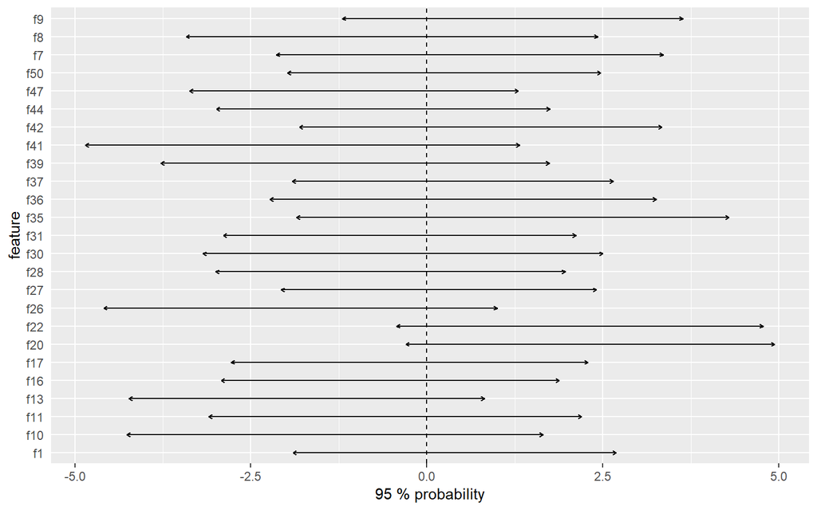

```r
plot.res(res, element = "g1")
```

# 8 Example 2: Synthetic data with continuous response

```r
cond.cont <- rnorm(10,1,7)

res2<-HOmics(data.matrix = data.matrix,
            agg.matrix = agg.matrix,
            cond = cond.cont,
            z.matrix = z.matrix,
            covar.matrix = NULL,
            cores = 4)
```

```
## cond is a numerical vector, a hierarchical linear model will be constructed
```

# 9 Example 3: Synthetic data with an extra categorical covariate

```r
covar<- rep(c("A","B"),5)

res3<-HOmics(data.matrix = data.matrix,
            agg.matrix = agg.matrix,
            cond = cond,
            z.matrix = z.matrix,
            covar.matrix = covar,
            cores = 4)
```

```
## cond is a factor, it has been converted to a numerical vector of 0s and 1s with 0 as the reference level. A hierarchical logistic model will be fitted
##  [1] 0 1 0 1 0 1 0 1 0 1
## covar.matrix has been converted to a numerical vector
```

# 10 Example 4: Synthetic data with an extra continuous covariate

```r
covariate <- rnorm(10,3,4)

res4<-HOmics(data.matrix = data.matrix,
            agg.matrix = agg.matrix,
            cond = cond,
            z.matrix = z.matrix,
            covar.matrix = covariate,
            cores = 4)
```

```
## cond is a factor, it has been converted to a numerical vector of 0s and 1s with 0 as the reference level. A hierarchical logistic model will be fitted
##  [1] 0 1 0 1 0 1 0 1 0 1
## covar.matrix will be included in the hierarchical model, as a continuous covariate
```

# 11 Example 4: Synthetic data with two extra continuous covariates

```r
co.matrix <- matrix(rnorm(20,3,4),nrow=10)

res4<-HOmics(data.matrix = data.matrix,
            agg.matrix = agg.matrix,
            cond = cond,
            z.matrix = z.matrix,
            covar.matrix = co.matrix,
            cores = 4)
```

```
## cond is a factor, it has been converted to a numerical vector of 0s and 1s with 0 as the reference level. A hierarchical logistic model will be fitted
##  [1] 0 1 0 1 0 1 0 1 0 1
```

# 12 Example 6: Ovarian cancer gene expression and miRNA integration

For this example we will work with data from three different sources:

- ExpressionSet obtained from bicoconductor’s package *curatedovarianData*
- Functional annotation obtained from the MSigDB (v 6.2 http://software.broadinstitute.org/gsea/msigdb/index.jsp) through *msigdbr*
- Prior information of target miRNA downloaded from TargetScan website (v 7.2 http://www.targetscan.org/vert_72/) and available as a data object in **HOmics**

With all these information we will perform a functional approach by analyzing each gene set in mSigDB related to ovarian cancer. For all genes in a gene set, we will fit a hierarchical model where prior information known about genes are their predicted miRNAs.

## 12.1 Data matrix

```r
# BiocManager::install("curatedOvarianData")

library(curatedOvarianData)
data(TCGA_eset)
TCGA_eset
```

```
## ExpressionSet (storageMode: lockedEnvironment)
## assayData: 13104 features, 578 samples
##   element names: exprs
## protocolData: none
## phenoData
##   sampleNames: TCGA.20.0987 TCGA.23.1031 ... TCGA.13.1819 (578
##     total)
##   varLabels: alt_sample_name unique_patient_ID ...
##     uncurated_author_metadata (31 total)
##   varMetadata: labelDescription
## featureData
##   featureNames: A1CF A2M ... ZZZ3 (13104 total)
##   fvarLabels: probeset gene
##   fvarMetadata: labelDescription
## experimentData: use 'experimentData(object)'
##   pubMedIds: 21720365
## Annotation: hthgu133a
```

Notice that TCGA_eset is an object of class *ExpressionSet*. We will compare ovarian cancer tumor samples in stage 4 with recurrence versus healthy samples. For that, we will subset the original *ExpressionSet* with the required constraints. Once subsetted the original TCGA_eset object, we will extract the expression data (with the function *exprs()*) and the phenotype variables (with the function *pData()*).

```r
pheno <- pData(TCGA_eset)
table(pheno$sample_type)
```

```
##
## healthy   tumor
##       8     570
```

```r
TCGA_subset <- TCGA_eset[,pheno$sample_type=="healthy" |
                           (pheno$sample_type=="tumor" & pheno$tumorstage==4 & pheno$recurrence_status=="recurrence")]

expr.m <- exprs(TCGA_subset)
dim(expr.m)
```

```
## [1] 13104    47
```

```r
pheno <- pData(TCGA_subset)
```

## 12.2 Response vector

Let’s obtain the condition vector.

```r
cond <- pheno$sample_type
cond
```

```
##  [1] "tumor"   "tumor"   "tumor"   "healthy" "healthy" "healthy" "tumor"
##  [8] "healthy" "healthy" "healthy" "healthy" "tumor"   "healthy" "tumor"
## [15] "tumor"   "tumor"   "tumor"   "tumor"   "tumor"   "tumor"   "tumor"
## [22] "tumor"   "tumor"   "tumor"   "tumor"   "tumor"   "tumor"   "tumor"
## [29] "tumor"   "tumor"   "tumor"   "tumor"   "tumor"   "tumor"   "tumor"
## [36] "tumor"   "tumor"   "tumor"   "tumor"   "tumor"   "tumor"   "tumor"
## [43] "tumor"   "tumor"   "tumor"   "tumor"   "tumor"
```

Notice that this is a character categorical vector.

## 12.3 Aggregated matrix

The aggregated matrix must contain the groups that will be analyzed, in this case each functional gene set is a group and will be specified in a row. Information is obtained from the MSigDB through *msigdbr* and then the **agg.matrix** is constructed. To get pathways in collection *curated gene sets* (C2) with keyword *ovarian* follow these steps:

```r
# install.packages(msigdbr)

library(msigdbr)

c2 = msigdbr(species = "Homo sapiens", category = "C2")

c2.ov <- c2[grep("OVARIAN", c2$gs_name),]
c2.ov
```

```
## # A tibble: 1,752 x 9
##    gs_name gs_id gs_cat gs_subcat human_gene_symb~ species_name entrez_gene
##    <chr>   <chr> <chr>  <chr>     <chr>            <chr>              <int>
##  1 BONOME~ M158~ C2     CGP       ACOT7            Homo sapiens       11332
##  2 BONOME~ M158~ C2     CGP       ASPSCR1          Homo sapiens       79058
##  3 BONOME~ M158~ C2     CGP       BOP1             Homo sapiens       23246
##  4 BONOME~ M158~ C2     CGP       C10orf2          Homo sapiens       56652
##  5 BONOME~ M158~ C2     CGP       CLN6             Homo sapiens       54982
##  6 BONOME~ M158~ C2     CGP       DNASE2           Homo sapiens        1777
##  7 BONOME~ M158~ C2     CGP       EHMT2            Homo sapiens       10919
##  8 BONOME~ M158~ C2     CGP       FCHO1            Homo sapiens       23149
##  9 BONOME~ M158~ C2     CGP       GLT25D1          Homo sapiens       79709
## 10 BONOME~ M158~ C2     CGP       GRK6             Homo sapiens        2870
## # ... with 1,742 more rows, and 2 more variables: gene_symbol <chr>,
## #   sources <chr>
```

And, by manipulating the results, we obtain the aggregated matrix.

```r
agg.table <- table(c2.ov$gs_name, c2.ov$human_gene_symbol)

agg.matrix <- as.matrix(as.data.frame.matrix(agg.table))

dim(agg.matrix)
```

```
## [1]   14 1496
```

```r
table(agg.matrix)  # 0s and 1s only
```

```
## agg.matrix
##     0     1
## 19192  1752
```

14 gene sets where selected.

## 12.4 Prior matrix

The prior matrix with miRNAs that target our set of genes is obtained from the downloaded information obtained at TargetScan.

```r
# install.packages("readr")

data("targets.hs.6.2", package="HOmics")

targets
```

```
## # A tibble: 718,233 x 11
##    `miR Family` `Gene ID` `Gene Symbol` `Transcript ID` `Species ID`
##    <chr>        <chr>     <chr>         <chr>                  <dbl>
##  1 miR-23-3p    ENSG0000~ A1BG          ENST0000026310~         9606
##  2 miR-23       ENSG0000~ A1BG          ENST0000026310~         9598
##  3 miR-23-3p    ENSG0000~ A1BG          ENST0000026310~         9544
##  4 miR-23       ENSG0000~ A1BG          ENST0000026310~         9615
##  5 miR-302-3p/~ ENSG0000~ A1CF          ENST0000037400~         9544
##  6 miR-302c-3p~ ENSG0000~ A1CF          ENST0000037400~         9606
##  7 miR-520      ENSG0000~ A1CF          ENST0000037400~         9598
##  8 miR-15/16/1~ ENSG0000~ A1CF          ENST0000037400~         9913
##  9 miR-15/16/1~ ENSG0000~ A1CF          ENST0000037400~         9615
## 10 miR-153      ENSG0000~ A1CF          ENST0000037400~         9598
## # ... with 718,223 more rows, and 6 more variables: `UTR start` <dbl>, `UTR
## #   end` <dbl>, `MSA start` <dbl>, `MSA end` <dbl>, `Seed match` <chr>,
## #   PCT <chr>
```

Let’s filter the targets to get only those with probability of conserved targeting (P<sub>CT</sub>) > 0.5 and generate the prior information matrix, i.e. **the z.matrix**.

```r
targets.f <- targets %>% mutate(PCT= as.numeric(PCT)) %>% filter(PCT >0.5)

z.table <- table(targets.f$`Gene Symbol`, targets.f$`miR Family`)

z.matrix <- as.matrix(as.data.frame.matrix(z.table))

z.matrix[z.matrix>1]<-1

table(z.matrix) # 0s and 1s only
```

```
## z.matrix
##       0       1
## 1714767  118666
```

To make sure that features (in this case genes) in the three matrices are the same, we do:

```r
common.genes <- intersect(intersect(rownames(expr.m), colnames(agg.matrix)),
                          rownames(z.matrix))

length(common.genes)
```

```
## [1] 775
```

```r
agg.matrix <- agg.matrix[,common.genes]

expr.m <- expr.m[common.genes,]

z.matrix <- z.matrix[common.genes,]
```

And finally, we just need to decide the number of cores and apply function **HOmics**.

```r
library(HOmics)

res6 <- HOmics(data.matrix = expr.m,
               agg.matrix  = agg.matrix,
               cond = cond,
               z.matrix = z.matrix,
               covar.matrix = NULL,
               cores = 6)
```

```
## cond is a factor, it has been converted to a numerical vector of 0s and 1s with healthy as the reference level. A hierarchical logistic model will be fitted
##  [1] 1 1 1 0 0 0 1 0 0 0 0 1 0 1 1 1 1 1 1 1 1 1 1 1 1 1 1 1 1 1 1 1 1 1 1 1
## [37] 1 1 1 1 1 1 1 1 1 1 1
```

```r
class(res6)
```

```
## [1] "HOmics"
```

```r
length(res6)
```

```
## [1] 14
```

Note that 6 cores were used in this case.

Let’s filter the results to obtain high probabiliy results (p > 0.95).

```r
res6.f.pos <- get.signif(res6, param = "p.pos",threshold = 0.95, as.data.frame = T)
```

```
## notice that this is a probability, so values above threshold will be selected
```

```r
res6.f.pos
```

```
## # A tibble: 9 x 11
##   group    feature  mean    sd `2.5%` `50%` `97.5%`  Rhat n.eff p.pos   p.neg
##   <chr>    <chr>   <dbl> <dbl>  <dbl> <dbl>   <dbl> <dbl> <dbl> <dbl>   <dbl>
## 1 BONOME_~ ACOT7    3.66  2.14   0.93  2.97    7.61  4.33    23 1     0.
## 2 BONOME_~ EHMT2    2.16  1.3    0.11  1.94    4.73  1.18    12 0.982 1.80e-2
## 3 MEINHOL~ RAD21    2.77  0.86   1.11  2.82    4.98  1.17    15 1     0.
## 4 OUELLET~ COL11A1  1.78  1.31  -0.26  1.62    5.12  1.04   172 0.950 4.97e-2
## 5 OUELLET~ CCNE1    3.1   1.06   1.11  3.12    5.23  1.19    64 1     0.
## 6 OUELLET~ KHSRP    2.94  1.27   0.68  2.95    5.42  1.94    15 1.000 3.00e-4
## 7 OUELLET~ STX5     2.32  1.41   0.26  2.11    5.91  1.26    30 0.991 9.00e-3
## 8 WAMUNYO~ DYRK2    4.28  2.93  -0.26  3.8    10.6   2.79    43 0.967 3.27e-2
## 9 WAMUNYO~ ESRP1    4.86  2.54   1.01  4.41   11.3   2.21    34 0.997 3.30e-3
```

```r
res6.f.neg <- get.signif(res6, param = "p.neg",threshold = 0.95, as.data.frame = T)
```

```
## notice that this is a probability, so values above threshold will be selected
```

```r
res6.f.neg
```

```
## # A tibble: 7 x 11
##   group     feature  mean    sd `2.5%` `50%` `97.5%`  Rhat n.eff  p.pos p.neg
##   <chr>     <chr>   <dbl> <dbl>  <dbl> <dbl>   <dbl> <dbl> <dbl>  <dbl> <dbl>
## 1 BONOME_O~ IGFBP5  -2.54  1.82  -6.95 -2.35    0.55  1.41    22 0.0477 0.952
## 2 MEINHOLD~ KIF13B  -1.87  1.01  -4.25 -1.76   -0.13  1.04    38 0.0157 0.984
## 3 MEINHOLD~ RIMBP2  -1.77  1.03  -4.13 -1.74    0.11  1.04    49 0.0353 0.965
## 4 OUELLET_~ NELL2   -2.89  2.01  -8.78 -2.49   -0.49  1.15    53 0.0037 0.996
## 5 OUELLET_~ CIRBP   -3.32  1.25  -6.01 -3.34   -1.12  1.71    13 0      1
## 6 OUELLET_~ GNA11   -2.1   1.13  -4.38 -2.15   -0.19  1.34    21 0.017  0.983
## 7 WAMUNYOK~ NELL2   -2.68  1.66  -6.53 -2.61    0.48  1.3     92 0.0433 0.957
```

And finally let’s plot results for pathway *BONOME_OVARIAN_CANCER_POOR_SURVIVAL_DN*

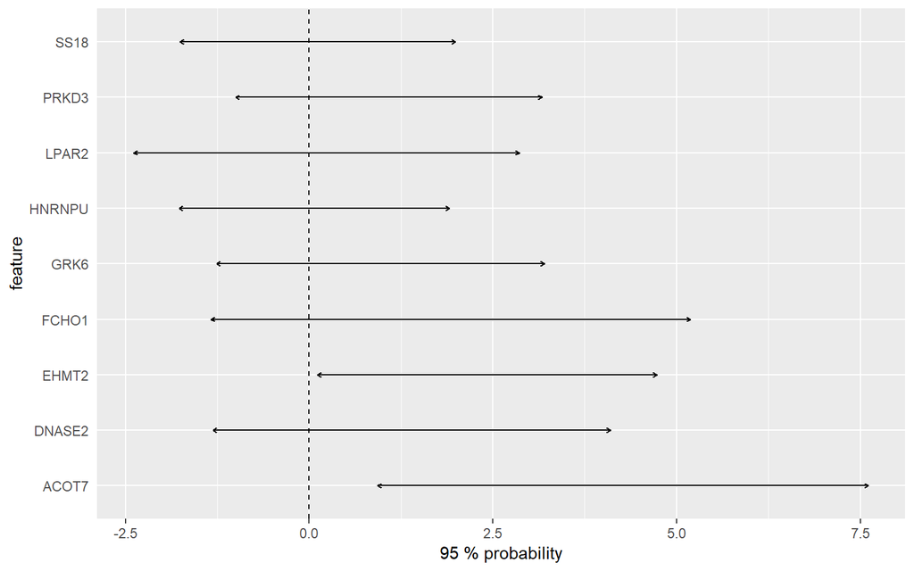

```r
plot.res(res6, element = "BONOME_OVARIAN_CANCER_POOR_SURVIVAL_DN")
```

# 13 Example 7: Methylation data

HOmics contains a specific function to analyze methylation array data. Check vignette.